# ass4

Tiffany Nguyen

2025-04-19

## Q 1 7.118 pg 364

```r
library(dplyr)
nzbirds <- read.csv("NZBIRDS.csv")
nzbirds_sample <- sample_n(nzbirds, 35)
```

```r
# calculate mean and standard deviation
bird_mean <- mean(nzbirds_sample$Body.Mass, na.rm=TRUE)
bird_sd <- sd(nzbirds_sample$Body.Mass, na.rm=TRUE)

# mean
bird_mean
```

```
## [1] 4400.286
```

```r
# standard deviation
bird_sd
```

```
## [1] 17086.55
```

```r
# construct 95% confidence interval
n_length <- length(nzbirds_sample$Body.Mass)
n_standard_error <- bird_sd / sqrt(n_length)
n_margin_error <- qt(0.975, df = n_length - 1)  * n_standard_error

n_ci <- c(bird_mean - n_margin_error, round((bird_mean + n_margin_error), 3))

# confidence interval
n_ci
```

```
## [1] -1469.15 10269.72
```

3. The calculated sample ci (-1469.1498943, 1.0269721^{4}) is a 95% confidence interval for the mean body mass of the New Zealand birds in the sample.
4. The calculated sample ci is (-1469.1498943, 1.0269721^{4}). The $\mu$ from the MINITAB printout for body mass is 9113 (estimated=4400.2857143), which is within the sample ci. The calculated interval is very likely to contain $\mu$ because the sample size is large enough (>30ish) to provide a reliable estimate of the population parameter.

```r
# b-d for egg length
egg_mean <- mean(nzbirds_sample$Egg.Length, na.rm=TRUE)
egg_sd <- sd(nzbirds_sample$Egg.Length, na.rm=TRUE)

# mean
egg_mean
```

```
## [1] 53.3
```

```r
# standard deviation
egg_sd
```

```
## [1] 38.19151
```

```r
# construct 95% confidence interval
egg_length <- length(nzbirds_sample$Egg.Length)
egg_standard_error <- egg_sd / sqrt(egg_length)
egg_margin_error <- qt(0.975, df = egg_length - 1) * egg_standard_error
egg_ci <- c(egg_mean - egg_margin_error, round((egg_mean + egg_margin_error), 3))

# confidence interval
egg_ci
```

```
## [1] 40.18076 66.41900
```

The calculated sample ci (40.1807585, 66.419) is a 95% confidence interval for the mean egg length of the New Zealand birds in the sample.

The calculated sample ci is (40.1807585, 66.419). The $\mu$ from the MINITAB printout for egg length is 61.06 (estimated=53.3), which is within the sample ci. The calculated interval is very likely to contain $\mu$ because the sample size is large enough (>30ish) to provide a reliable estimate of the population parameter.

## Q 2 7.120 pg 365

$$\text{using } (1-\alpha) \text{ 100% Confidence Interval: }
(\bar{y}_{1}-\bar{y}_{2}) \pm
z_{\alpha/2}\sqrt{\frac{s_{1}^{2}}{n_{1}}+\frac{s_{2}^{2}}{n}} \newline
(1312-1352) \pm 1.645\sqrt{ \frac{422^{2}}{100}+\frac{271^{2}}{47} } =
(-40) \pm 95.117627893 = (-135.11762789, 55.11762789)$$

$$\text{using } (1-\alpha) \text{ 100% Confidence Interval for ratio of
Two Population Variances: } \left(\frac{s_{1}^{2}}{s_{2}^{2}}\right)
\left(\frac{1}{F_{\alpha/2,(v_{1},v_{2})}}\right) \leq
\frac{\sigma_{1}^{2}}{\sigma_{2}^{2}} \leq
\left(\frac{s_{1}^{2}}{s_{2}^{2}}\right) F_{\alpha/2,(v_{2},v_{1})}
\newline
\text{F-values given from hint: } F_{0.05(99,46)}=1.54818 \text{ and }
F_{0.05(46,99)} = 1.49194 \newline
\left(\frac{422^{2}}{271^{2}}\right) \left(\frac{1}{1.54818}\right) \leq
\frac{\sigma_{1}^{2}}{\sigma_{2}^{2}} \leq
\left(\frac{422^{2}}{271^{2}}\right) (1.49194) = 1.5662636 \le
\frac{\sigma_{1}^{2}}{\sigma_{2}^{2}} \le 3.6177427$$

Yes, there is evidence that the two shear stress variances differ. The confidence interval for the ratio of the two population variances is (1.5662636, 3.6177427), which does not include 1. This indicates that the variances are significantly different from each other, suggesting that the two sheer stress variances DO differ.

## Q 3 7.128 pg 367

1. Show that $y^{2}/\sigma^{2}$ has a chi-square distribution with 1 degree of freedom

Given that y is a random sample of size n = 1 from a normal distribution with mean 0 and unknown variance $\sigma^{2}$, we can express the distribution as:

$$y \sim N(0, \sigma^{2})$$

Since $\mu=0$, we have:

$$\frac{y}{\sigma} \sim N(0,1)$$

Squaring both sides, we get:

$$\Big(\frac{y^{2}}{\sigma^{2}}\Big) \sim \chi^{2} (1)$$

Then:

$$\frac{y^{2}}{\sigma^{2}} \sim \chi^{2} (1) \text{ because }
\frac{y}{\sigma} \sim N(0,1)$$

yay!

We will use the result from part a to help calculate the confidence interval for $\sigma^{2}$.

$$\text{Result from part a: } \frac{y^{2}}{\sigma^{2}} \sim \chi^{2} (1)$$

Let X = $\frac{y^{2}}{\sigma^{2}}$. Since X = $\chi^{2}(1)$, the 95% confidence interval can be derived from the chi-square distribution with 1 degree of freedom.

$$P\Big(\chi^{2}_{1-\alpha/2} \leq \frac{y^{2}}{\sigma^{2}} \leq
\chi^{2}_{\alpha/2}\Big) = P\Big(\chi^{2}_{0.025} \leq
\frac{y^{2}}{\sigma^{2}} \leq \chi^{2}_{0.975}\Big) =
P\Big(\frac{Y^{2}}{\chi^{2}_{\alpha/2}} \le \sigma^{2} \le
\frac{Y^{2}}{\chi^{2}_{1-\alpha/2}} \Big)$$

Using chi-square distribution table, we get the interval:

$$P\Big(\frac{Y^{2}}{5.024} \le \sigma^{2} \le \frac{Y^{2}}{0.000982}
\Big) \text{ or } P\Big(\frac{Y^{2}}{5.024}, \frac{Y^{2}}{0.000982}
\Big)$$

## Q 4 8.24 pg 390

1. $H_{0}$: The mean surface roughness of coated interior pipe, $\mu$, is 2 micrometers. $H_{1}$: The mean surface roughness of coated interior pipe, $\mu$, differs from 2 micrometers.
2. T: -1.02 p-value: 0.322

```r
qt(0.975, df=19)
```

```
## [1] 2.093024
```

The rejection region for the hypothesis test, using $\alpha = 0.05 (\alpha/2=0.025)$, is

$$t < -2.093 \text{ or } t > 2.093$$

## Q 5 8.28 pg 392

```r
lakes <- read.csv("WISCLAKES.csv")

# mean and sd for test statistic
mean <- mean(lakes$DOC)
sd <- sd(lakes$DOC)
n <- length(lakes$DOC)
test_statistic <- (mean - 15) / (sd / sqrt(n))
test_statistic
```

```
## [1] -0.1866753
```

```r
# can also do this i guess
t.test(lakes$DOC, mu=15, alternative="two.sided", conf.level=0.90)
```

```
##
##  One Sample t-test
##
## data:  lakes$DOC
## t = -0.18668, df = 24, p-value = 0.8535
## alternative hypothesis: true mean is not equal to 15
## 90 percent confidence interval:
##  10.08013 18.95187
## sample estimates:
## mean of x
##    14.516
```

This is calculated using the formula:
$$t = \frac{\bar{y} - \mu}{s / \sqrt{n}} = \frac{14.52 - 15}{12.96 /
\sqrt{25}} = -0.185$$

The p-value (0.8535) is greater than the significance level $(\alpha=0.10)$ so we fail to reject the null hypothesis. Therefore the sample is representative of all Wisconsin lakes for the characteristic, dissolved organic compound (DOC).

t-value (-1.711) is taken from table with $n-1=24$ degrees of freedom

$$t = \frac{\bar{y} - \mu}{s / \sqrt{n}} \implies t=
\Big(\frac{s}{\sqrt{n}} \Big) = \bar{y}-\mu_{0} \implies \bar{y} =
\mu_{0} + t \Big(\frac{s}{\sqrt{n}} \Big) = 15 \pm 1.711\Big(
\frac{12.96}{\sqrt{25}} \Big) = (10.565, 19.435) \newline$$

Now we find the probability of rejecting $H_{0}$ (power):

$$P(\bar{y}<10.565 | \mu=14) + P(\bar{y}>19.435 | \mu=14) = P \left(
t<\frac{10.565-14}{\frac{12.96}{\sqrt{25}} } \right) + P \left(
t>\frac{19.435-14}{\frac{12.96}{\sqrt{25}} } \right) = \newline
P(t<-1.33) + P(t>2.10) = 0.0980+0.0232 = 0.1212$$

The power of the test is 0.1212, which is the probability of rejecting the null hypothesis when the true mean DOC is 14. Since the power is low, the test is not very effective in detecting a true mean of 14 grams/$m^{3}$ if it differs from 15 grams/$m^{3}$.

## Q 6 8.44 pg 401

```r
orchard <- read.csv("ORCHARD.csv")
orchard <- orchard[-5,] # remove that dumbass NA row

clear_cloudy <- orchard$RATIO[orchard$CONDITION %in% c("CLEAR", "CLOUD")]
froggy <- orchard$RATIO[orchard$CONDITION == "FOG"]

# calculate means and standard deviations
clear_cloudy_mean <- mean(clear_cloudy)
clear_cloudy_sd <- sd(clear_cloudy)
froggy_mean <- mean(froggy)
froggy_sd <- sd(froggy)

# calculate sample sizes
clear_cloudy_n <- length(clear_cloudy)
froggy_n <- length(froggy)

# calculate pooled sd
s_p <- ((clear_cloudy_n - 1) * clear_cloudy_sd^2 + (froggy_n - 1) * froggy_sd^2) / (clear_cloudy_n + froggy_n - 2)

# calculate t-statistic
t_stat <- ((clear_cloudy_mean - froggy_mean)) / sqrt(s_p * (1 / clear_cloudy_n + 1 / froggy_n))
t_stat
```

```
## [1] 2.04675
```

```r
cv <- qt(0.975, df = clear_cloudy_n + froggy_n - 2)
cv
```

```
## [1] 2.228139
```

```r
# another way i guess (idk if this one works, so im stick with my calculated value)
t.test(clear_cloudy, froggy, alternative = "two.sided", conf.level = 0.95)
```

```
##
##  Welch Two Sample t-test
##
## data:  clear_cloudy and froggy
## t = 1.7459, df = 4.2617, p-value = 0.1514
## alternative hypothesis: true difference in means is not equal to 0
## 95 percent confidence interval:
##  -0.09862346  0.45562346
## sample estimates:
## mean of x mean of y
##   0.45225   0.27375
```

We use these formulas (I give up using my phone as a calculator. R can do it, so here’s the formulas to show that I know how to do it :( ):

$$\text{Calculate the pooled sd: } s_{p}^{2} = \frac{ (n_{1} - 1)s_{1}^{2}
+ (n_{2} - 1)s_{2}^{2} }{ n_{1} + n{2} - 2 } \newline
\text{Calculate the test statistic: } T=\frac{ (\bar{y}_{1} -
\bar{y}_{2}) - D_{0} }{ \sqrt{ s_{p}^{2} \Big(\frac{1}{2_{1}} +
\frac{1}{n_{2}} \Big) } }$$

## Q 7 8.84 pg 425

This refers to 8.39 NOT 8.33

```r
gasturbine <- read.csv("GASTURBINE.csv")

# get respective dataframes for each engine type
traditional <- gasturbine %>% filter(ENGINE == "Traditional")
aeroderiv <- gasturbine %>% filter(ENGINE == "Aeroderiv")
advanced <- gasturbine %>% filter(ENGINE == "Advanced")

# get heatrate for each engine
trad_heat <- traditional$HEATRATE
aero_heat <- aeroderiv$HEATRATE
adv_heat <- advanced$HEATRATE

# get total number of engines for each type
trad_length <- nrow(traditional)
aero_length <- nrow(aeroderiv)
adv_length <- nrow(advanced)

alpha <- 0.05

# calculate F statistic
f_stat <- var(aero_heat) / var(trad_heat)
f_stat
```

```
## [1] 4.296996
```

```r
# calculate acceptance/rejection regions
qf(c(alpha/2, 1-alpha/2), aero_length - 1, trad_length - 1)
```

```
## [1] 0.1991693 2.7633350
```

```r
# this also works
var.test(aero_heat, trad_heat)
```

```
##
##  F test to compare two variances
##
## data:  aero_heat and trad_heat
## F = 4.297, num df = 6, denom df = 38, p-value = 0.004234
## alternative hypothesis: true ratio of variances is not equal to 1
## 95 percent confidence interval:
##   1.555004 21.574593
## sample estimates:
## ratio of variances
##           4.296996
```

```r
# calculate the F statistic
f_stat <- var(aero_heat) / var(adv_heat)
f_stat
```

```
## [1] 17.24913
```

```r
# calculate acceptance/rejection regions
qf(c(alpha/2, 1-alpha/2), aero_length - 1, adv_length - 1)
```

```
## [1] 0.1934834 3.1283400
```

```r
# this also works
var.test(aero_heat, adv_heat)
```

```
##
##  F test to compare two variances
##
## data:  aero_heat and adv_heat
## F = 17.249, num df = 6, denom df = 20, p-value = 1.192e-06
## alternative hypothesis: true ratio of variances is not equal to 1
## 95 percent confidence interval:
##   5.513829 89.150428
## sample estimates:
## ratio of variances
##           17.24913
```

The F statistic is 17.24913 and the acceptance region is (0.1934834, 3.1283400). Since the F statistic is greater than the upper limit of the acceptance region, we reject the null hypothesis. There is a difference in the variation of heatrates of aeroderivative and advanced engines. The assumption of equal variances in Exercise 8.39 may not be valid.

## Q 8 8.99 pg 438

1. $H_{0}$: The variance of the two sites are equal $H_{1}$: The variance of the two sites are not equal

```r
gobiants <- read.csv("GOBIANTS.csv")

# get the ant species for each region
dry <- (gobiants %>% filter(Region == "Dry Steppe"))$AntSpecies
gobi <- (gobiants %>% filter(Region == "Gobi Desert"))$AntSpecies

# calculate F statistic
f_stat <- var(dry) / var(gobi)
f_stat
```

```
## [1] 1.368432
```

```r
# this also works
var.test(dry, gobi)
```

```
##
##  F test to compare two variances
##
## data:  dry and gobi
## F = 1.3684, num df = 4, denom df = 5, p-value = 0.7264
## alternative hypothesis: true ratio of variances is not equal to 1
## 95 percent confidence interval:
##   0.1852264 12.8146380
## sample estimates:
## ratio of variances
##           1.368432
```

The test statistic is 1.368432.

```r
alpha <- 0.05

# calculate acceptance/rejection regions
qf(c(alpha/2, 1-alpha/2), length(dry) - 1, length(gobi) - 1)
```

```
## [1] 0.1067866 7.3878858
```

The calculated rejection region for the test if $\alpha=0.05$ is t < 0.1067866 or t > 7.3878858).

```r
# degrees of freedom cause i dont wanna type alladat
df1 <- length(dry) - 1
df2 <- length(gobi) - 1

# calculate p-value based on which tail lol
p_value <- 2 * min(pf(f_stat, df1, df2), 1 - pf(f_stat, df1, df2))
p_value
```

```
## [1] 0.7263776
```

The p-value is 0.7263776

5. The variances of the two sites are not significantly different because the test statistic (1.368432) does not fall in the rejection region t < 0.1067866 or t > 7.3878858 and the p-value (0.7263776) is greater than the significance level of 0.05. Therefore, we fail to reject the null hypothesis that the variances of the two sites are equal.

## Q 9 8.104 pg 439

```r
thruput <- read.csv("THRUPUT.csv")

# manual calculations for the latex
human <- thruput$HUMAN
auto <- thruput$AUTO

diff <- human-auto

# get mean sample of differences
mean_diff <- mean(diff) # 32.5625

# get sd of the differences
sd_diff <- sd(diff) # 35.03243

t_stat <- mean_diff / (sd_diff/sqrt(8)) # -2.629011
t_stat
```

```
## [1] -2.629011
```

```r
t.test(thruput$HUMAN, thruput$AUTO, paired = TRUE)
```

```
##
##  Paired t-test
##
## data:  thruput$HUMAN and thruput$AUTO
## t = -2.629, df = 7, p-value = 0.03396
## alternative hypothesis: true mean difference is not equal to 0
## 95 percent confidence interval:
##  -61.850346  -3.274654
## sample estimates:
## mean difference
##        -32.5625
```

The rejection region requires $\alpha/2=0.025$, so we use the t-distribution with $n-1=7$ degrees of freedom to find the critical value: $t_{0.025} = 2.365$. Therefore the rejection region is t < -2.365 or t > 2.365.

The calculated t-statistic (-2.629011) is less than -2.365, so we reject the null hypothesis that the mean difference in throughput between the human and automated method is 0. This suggests that there is a statistical significant difference between the two.

## Q 10

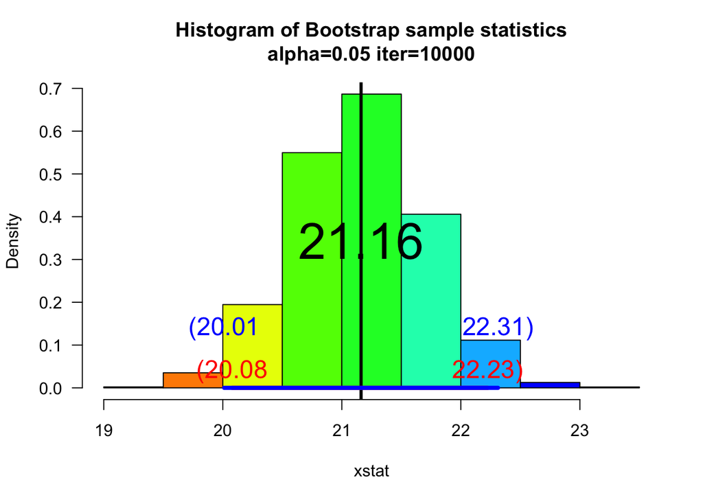

```
## $fun
## [1] "mean"
##
## $x
##  [1] 23.195 20.399 19.898 19.865 30.014 18.821 21.232 18.313 23.574 21.047
## [11] 21.535 21.336 17.695 18.497 14.274 14.664 22.593 18.963 25.515 25.019
## [21] 22.053 22.871 23.006 23.829 19.038 21.735 21.461 21.659 21.703 21.049
##
## $t
## [1] 2.065773
##
## $ci
##     2.5%    97.5%
## 20.07910 22.22545
##
## $cit
## [1] 20.01155 22.31198
```

```r
set.seed(35)

myboot <- function(iter = 10000, x, fun = "mean", alpha = 0.05, mean, ...) {

  n = length(x) # sample size

  # Bootstrap resampling
  y = sample(x, n * iter, replace = TRUE)
  rs.mat = matrix(y, nrow = n, ncol = iter, byrow = TRUE)
  xstat = apply(rs.mat, 2, fun) # bootstrap sample statistics

  # Bootstrap confidence interval
  ci_bootstrap = quantile(xstat, c(alpha / 2, 1 - alpha / 2))

  # Theoretical confidence interval using sample statistics
  sample_mean = mean(x)
  sample_sd = sd(x)
  error_margin = qt(1 - alpha / 2, df = n - 1) * (sample_sd / sqrt(n))
  ci_theoretical = c(sample_mean - error_margin, sample_mean + error_margin)

  # Calculate the t-statistic
  t_statistic = (sample_mean - mean) / (sample_sd / sqrt(n))

  # Plot histogram of bootstrap sample statistics
  para = hist(xstat, breaks=11, freq = FALSE, las = 1,
              main = paste("Histogram of Bootstrap sample statistics", "\n", "alpha=", alpha, " iter=", iter, sep = ""), col = rainbow(11),
              ...)

  # Plot point estimate
  abline(v = sample_mean, lwd = 3, col = "Black") # Vertical line

  # Plot bootstrap confidence interval
  segments(ci_bootstrap[1], 0, ci_bootstrap[2], 0, lwd = 4, col = "Red")
  text(ci_bootstrap[1], 0, paste("(", round(ci_bootstrap[1], 2), sep = ""), col = "Red", cex = 1.5, pos = 3)
  text(ci_bootstrap[2], 0, paste(round(ci_bootstrap[2], 2), ")", sep = ""), col = "Red", cex = 1.5, pos = 3)

  # Plot theoretical confidence interval
  segments(ci_theoretical[1], 0, ci_theoretical[2], 0, lwd = 4, col = "Blue")
  text(ci_theoretical[1], 0.1, paste("(", round(ci_theoretical[1], 2), sep = ""), col = "Blue", cex = 1.5, pos = 3)
  text(ci_theoretical[2], 0.1, paste(round(ci_theoretical[2], 2), ")", sep = ""), col = "Blue", cex = 1.5, pos = 3)

  # Plot point estimate text
  text(sample_mean, max(para$density) / 2, round(sample_mean, 2), cex = 3, col = "Black")

  return(list(
    fun = fun,
    x = x,
    t = t_statistic,
    ci = ci_bootstrap,
    cit = ci_theoretical
  )) # Some output to use if necessary

}

sam<-round(rnorm(30,mean=20,sd=3),3)

myboot(x=sam, mean=20)
```